# Forecasting series temporales con Python y Scikit-learn

**Joaquín Amat Rodrigo**

*Febrero, 2021 (última actualización Diciembre 2021)*

Más sobre ciencia de datos: [**cienciadedatos.net**](https://cienciadedatos.net)

- [Predicción (forecasting) de la demanda eléctrica con Python](https://www.cienciadedatos.net/documentos/py29-forecasting-demanda-energia-electrica-python.html)
- [Predicción (forecasting) de visitas a página web con machine learning](https://www.cienciadedatos.net/documentos/py37-forecasting-visitas-web-machine-learningn.html)
- [skforecast](https://joaquinamatrodrigo.github.io/skforecast/)

## Introducción

Una [serie temporal](https://es.wikipedia.org/wiki/Serie_temporal) (*time series*) es una sucesión de datos ordenados cronológicamente, espaciados a intervalos iguales o desiguales. El proceso de [*Forecasting*](https://en.wikipedia.org/wiki/Forecasting) consiste en predecir el valor futuro de una serie temporal, bien modelando la serie temporal únicamente en función de su comportamiento pasado (autorregresivo) o empleando otras variables externas a la serie temporal.

A lo largo de este documento, se describe cómo utilizar modelos de regresión de **Scikit-learn** para realizar *forecasting* sobre series temporales. En concreto, se hace uso de [**Skforecast**](https://joaquinamatrodrigo.github.io/skforecast/), una librería sencilla que contiene las clases y funciones necesarias para adaptar cualquier modelo de regresón de **Scikit-learn** a problemas de *forecasting*. Para un caso de uso más detallado visitar [predicción (forecasting) de la demanda eléctrica con Python](https://www.cienciadedatos.net/documentos/py29-forecasting-demanda-energia-electrica-python.html).

## Multi-Step Time Series Forecasting

Cuando se trabaja con series temporales, raramente se quiere predecir solo el siguiente elemento de la serie ($t_{+1}$), sino todo un intervalo futuro o un punto alejado en el tiempo ($t_{+n}$). A cada paso de predicción se le conoce como *step*.

Existen varias estrategias que permiten generar este tipo de predicciones múltiples.

**Recursive multi-step forecasting**

Dado que, para predecir el momento $t_{n}$ se necesita el valor de $t_{n-1}$, y $t_{n-1}$ se desconoce, es necesario hacer predicciones recursivas en las que, cada nueva predicción, se basa en la predicción anterior. A este proceso se le conoce como *recursive forecasting* o *recursive multi-step forecasting*.

[figure not shown]

La principal adaptación que se necesita hacer para aplicar modelos de [Scikit-learn](https://www.cienciadedatos.net/documentos/py06_machine_learning_python_scikitlearn.html) a problemas de *recursive multi-step forecasting* es transformar la serie temporal en un matriz en la que, cada valor, está asociado a la ventana temporal (lags) que le preceden. Esta estrategia de *forecasting* pueden generarse fácilmente con las clases `ForecasterAutoreg` y `ForecasterAutoregCustom` de la librería **Skforecast**.

[figure not shown]

*Tranformación de una serie temporal en una matriz de 5 lags y un vector con el valor de la serie que sigue a cada fila de la matriz.*

Este tipo de transformación también permite incluir variables exógenas a la serie temporal.

[figure not shown]

*Transformación de una serie temporal junto con una variable exógena.*

**Direct multi-step forecasting**

El método *direct multi-step forecasting* consiste en entrenar un modelo distinto para cada *step*. Por ejemplo, si se quieren predecir los siguientes 5 valores de una serie temporal, se entrenan 5 modelos distintos, uno para cada *step*. Como resultado, las predicciones son independientes unas de otras.

La principal complejidad de esta aproximación consiste en generar correctamente las matrices de entrenamiento para cada modelo. Todo este proceso está automatizado en la clase `ForecasterAutoregMultiOutput` de la librería **Skforecast**. También es importante tener en cuenta que esta estrategia tiene un coste computacional más elevado ya que requiere entrenar múltiples modelos. En el siguiente esquema se muestra el proceso para un caso en el que se dispone de la variable respuesta y dos variables exógenas.

[figure not shown]

*Transformación de una serie temporal en en las matrices necesarias para entrenar un modelo direct multi-step forecasting.*

**Multiple output forecasting**

Determinados modelos son capaces de predecir de forma simultánea varios valores de una secuencia (*one-shot*). Un ejemplo de modelo con esta capacidad son las redes neuronales LSTM.

## Forecasting autorregresivo recursivo

Se dispone de una serie temporal con el gasto mensual (millones de dólares) en fármacos con corticoides que tuvo el sistema de salud Australiano entre 1991 y 2008. Se pretende crear un modelo autoregresivo capaz de predecir el futuro gasto mensual.

### Librerías

Las librerías utilizadas en este documento son:

```python
# Tratamiento de datos
# ==============================================================================
import numpy as np
import pandas as pd

# Gráficos
# ==============================================================================
import matplotlib.pyplot as plt
%matplotlib inline

# Configuración warnings
# ==============================================================================
import warnings
warnings.filterwarnings('ignore')
```

Además de las anteriores, se utiliza [**Skforecast**](https://github.com/JoaquinAmatRodrigo/skforecast), una librería sencilla que contiene las clases y funciones necesarias para adaptar cualquier modelo de regresón de **Scikit-learn** a problemas de *forecasting*. Puede instalarse de las siguientes formas:

`pip install skforecast`

Última versión (inestable):

`pip install git+https://github.com/JoaquinAmatRodrigo/skforecast#master`

```python
# Modelado y Forecasting
# ==============================================================================
from sklearn.linear_model import LinearRegression
from sklearn.linear_model import Lasso
from sklearn.ensemble import RandomForestRegressor
from sklearn.metrics import mean_squared_error

from skforecast.ForecasterAutoreg import ForecasterAutoreg
from skforecast.ForecasterAutoregCustom import ForecasterAutoregCustom
from skforecast.ForecasterAutoregMultiOutput import ForecasterAutoregMultiOutput
from skforecast.model_selection import grid_search_forecaster
from skforecast.model_selection import backtesting_forecaster
from skforecast.model_selection import backtesting_forecaster_intervals

from joblib import dump, load
```

### Datos

Los datos empleados en los ejemplos de este documento se han obtenido del magnífico libro [Forecasting: Principles and Practice by Rob J Hyndman and George Athanasopoulos](https://otexts.com/fpp3/).

```python
# Descarga de datos
# ==============================================================================
url = 'https://raw.githubusercontent.com/JoaquinAmatRodrigo/skforecast/master/data/h2o.csv'
datos = pd.read_csv(url, sep=',')
```

La columna *fecha* se ha almacenado como `string`. Para convertirla en `datetime`, se emplea la función `pd.to_datetime()`. Una vez en formato `datetime`, y para hacer uso de las funcionalidades de **pandas**, se establece como índice. Además, dado que los datos son mensuales, se indica la frecuencia (*Monthly Started 'MS'*).

```python
# Preparación del dato
# ==============================================================================
datos['fecha'] = pd.to_datetime(datos['fecha'], format='%Y/%m/%d')
datos = datos.set_index('fecha')
datos = datos.rename(columns={'x': 'y'})
datos = datos.asfreq('MS')
datos = datos['y']
datos = datos.sort_index()
```

Se verifica que la serie temporal está completa.

```python
# Verificar que un índice temporal está completo
# ==============================================================================
(datos.index == pd.date_range(start=datos.index.min(),
                              end=datos.index.max(),
                              freq=datos.index.freq)).all()
```

```
True
```

```python
# Completar huecos en un índice temporal
# ==============================================================================
# datos.asfreq(freq='30min', fill_value=np.nan)
```

Se utilizan los últimos 36 meses como conjunto de test para evaluar la capacidad predictiva del modelo.

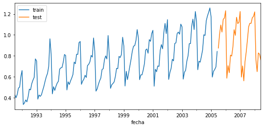

```python
# Separación datos train-test
# ==============================================================================
steps = 36
datos_train = datos[:-steps]
datos_test  = datos[-steps:]

fig, ax=plt.subplots(figsize=(9, 4))
datos_train.plot(ax=ax, label='train')
datos_test.plot(ax=ax, label='test')
ax.legend();
```

### ForecasterAutoreg

Se crea y entrena un modelo `ForecasterAutoreg` a partir de un regresor `RandomForestRegressor` y una ventana temporal de 6 lags. Esto último significa que, el modelo, utiliza como predictores los 6 meses anteriores.

```python
# Crear y entrenar forecaster
# ==============================================================================
forecaster_rf = ForecasterAutoreg(
                    regressor=RandomForestRegressor(random_state=123),
                    lags=6
                )

forecaster_rf.fit(y=datos_train)

forecaster_rf
```

```
=======================ForecasterAutoreg=======================
Regressor: RandomForestRegressor(random_state=123)
Lags: [1 2 3 4 5 6]
Exogenous variable: False, None
Parameters: {'bootstrap': True, 'ccp_alpha': 0.0, 'criterion': 'mse', 'max_depth': None, 'max_features': 'auto', 'max_leaf_nodes': None, 'max_samples': None, 'min_impurity_decrease': 0.0, 'min_impurity_split': None, 'min_samples_leaf': 1, 'min_samples_split': 2, 'min_weight_fraction_leaf': 0.0, 'n_e…
```

### Predicciones

Una vez entrenado el modelo, se predicen los datos de test (36 meses a futuro).

```python
# Predicciones
# ==============================================================================
steps = 36
predicciones = forecaster_rf.predict(steps=steps)
# Se añade el índice temporal a las predicciones
predicciones = pd.Series(data=predicciones, index=datos_test.index)
predicciones.head()
```

```
fecha
2005-07-01    0.866263
2005-08-01    0.874688
2005-09-01    0.951697
2005-10-01    0.991223
2005-11-01    0.952589
Freq: MS, dtype: float64
```

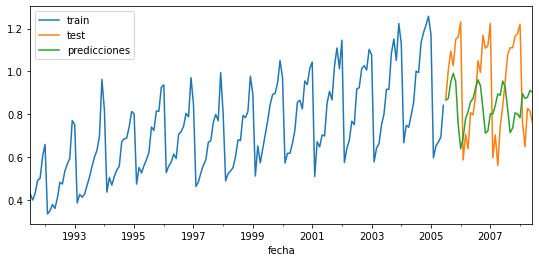

```python
# Gráfico
# ==============================================================================
fig, ax = plt.subplots(figsize=(9, 4))
datos_train.plot(ax=ax, label='train')
datos_test.plot(ax=ax, label='test')
predicciones.plot(ax=ax, label='predicciones')
ax.legend();
```

### Error de las predicciones en el conjunto de test

Se cuantifica el error que comete el modelo en sus predicciones. En este caso, se emplea como métrica el *mean squared error (mse)*.

```python
# Error
# ==============================================================================
error_mse = mean_squared_error(
                y_true = datos_test,
                y_pred = predicciones
            )
print(f"Error de test (mse): {error_mse}")
```

```
Error de test (mse): 0.0665147739321922
```

### Ajuste de hiperparámetros (*tuning*)

El `ForecasterAutoreg` entrenado ha utilizado una ventana temporal de 6 lags y un modelo [Random Forest](https://www.cienciadedatos.net/documentos/py08_random_forest_python.html) con los hiperparámetros por defecto. Sin embargo, no hay ninguna razón por la que estos valores sean los más adecuados.

Para identificar la mejor combinación de lags e hiperparámetros, la librería **Skforecast** dispone de las estrategias de [validación cruzada y backtesting](https://joaquinamatrodrigo.github.io/skforecast/0.3/guides/cross-validation-backtest.html). Independientemente de la estrategia utilizada, es importante no incluir los datos de test en el proceso de búsqueda para no caer en problemas de *overfitting*. En este caso, se utiliza [*time series cross-validation*](https://joaquinamatrodrigo.github.io/skforecast/0.3/guides/cross-validation-backtest.html) en el conjunto de datos de entrenamiento. Para el primer *fold*, el 50% inicial de las observaciones son los datos de entrenamiento y los siguientes 10 *steps* respresentan el set de validación. En los *folds* sucesivos, el conjunto de entrenamiento contendrá todos los datos utilizados en el *fold* anterior y los siguientes 10 *steps* se utilizarán como nuevos datos de validación. Este proceso se repetirá hasta utilizar todo el conjunto de datos de entrenamiento.

```python
# Grid search de hiperparámetros
# ==============================================================================
forecaster_rf = ForecasterAutoreg(
                    regressor = RandomForestRegressor(random_state=123),
                    lags      = 12 # Este valor será remplazado en el grid search
                 )

# Hiperparámetros del regresor
param_grid = {'n_estimators': [100, 500],
              'max_depth': [3, 5, 10]}

# Lags utilizados como predictores
lags_grid = [10, 20]

resultados_grid = grid_search_forecaster(
                        forecaster  = forecaster_rf,
                        y           = datos_train,
                        param_grid  = param_grid,
                        lags_grid   = lags_grid,
                        steps       = 10,
                        method      = 'cv',
                        metric      = 'mean_squared_error',
                        initial_train_size    = int(len(datos_train)*0.5),
                        allow_incomplete_fold = False,
                        return_best = True,
                        verbose     = False
                   )
```

```
2021-12-01 21:03:53,033 root       INFO  Number of models compared: 12
2021-12-01 21:04:36,690 root       INFO  Refitting `forecaster` using the best found parameters and the whole data set:
lags: [ 1  2  3  4  5  6  7  8  9 10 11 12 13 14 15 16 17 18 19 20]
params: {'max_depth': 10, 'n_estimators': 500}
```

```python
# Resultados Grid Search
# ==============================================================================
resultados_grid
```

|  | lags | params | metric | max_depth | n_estimators |
| --- | --- | --- | --- | --- | --- |
| 11 | [1, 2, 3, 4, 5, 6, 7, 8, 9, 10, 11, 12, 13, 14... | {'max_depth': 10, 'n_estimators': 500} | 0.005271 | 10 | 500 |
| 10 | [1, 2, 3, 4, 5, 6, 7, 8, 9, 10, 11, 12, 13, 14... | {'max_depth': 10, 'n_estimators': 100} | 0.005331 | 10 | 100 |
| 9 | [1, 2, 3, 4, 5, 6, 7, 8, 9, 10, 11, 12, 13, 14... | {'max_depth': 5, 'n_estimators': 500} | 0.005354 | 5 | 500 |
| 8 | [1, 2, 3, 4, 5, 6, 7, 8, 9, 10, 11, 12, 13, 14... | {'max_depth': 5, 'n_estimators': 100} | 0.005514 | 5 | 100 |
| 7 | [1, 2, 3, 4, 5, 6, 7, 8, 9, 10, 11, 12, 13, 14... | {'max_depth': 3, 'n_estimators': 500} | 0.005744 | 3 | 500 |
| 6 | [1, 2, 3, 4, 5, 6, 7, 8, 9, 10, 11, 12, 13, 14... | {'max_depth': 3, 'n_estimators': 100} | 0.005821 | 3 | 100 |
| 5 | [1, 2, 3, 4, 5, 6, 7, 8, 9, 10] | {'max_depth': 10, 'n_estimators': 500} | 0.026603 | 10 | 500 |
| 4 | [1, 2, 3, 4, 5, 6, 7, 8, 9, 10] | {'max_depth': 10, 'n_estimators': 100} | 0.028092 | 10 | 100 |
| 2 | [1, 2, 3, 4, 5, 6, 7, 8, 9, 10] | {'max_depth': 5, 'n_estimators': 100} | 0.028693 | 5 | 100 |
| 3 | [1, 2, 3, 4, 5, 6, 7, 8, 9, 10] | {'max_depth': 5, 'n_estimators': 500} | 0.028870 | 5 | 500 |
| 1 | [1, 2, 3, 4, 5, 6, 7, 8, 9, 10] | {'max_depth': 3, 'n_estimators': 500} | 0.029387 | 3 | 500 |
| 0 | [1, 2, 3, 4, 5, 6, 7, 8, 9, 10] | {'max_depth': 3, 'n_estimators': 100} | 0.030020 | 3 | 100 |

Los mejores resultados se obtienen si se utiliza una ventana temporal de 20 lags y una configuración de *Random Forest* {'max_depth': 10, 'n_estimators': 500}.

### Modelo final

Finalmente, se entrena de nuevo un `ForecasterAutoreg` con la configuración óptima encontrada mediante validación. Este paso no es necesario si se indica `return_best = True` en la función `grid_search_forecaster()`.

```python
# Crear y entrenar forecaster con mejores hiperparámetros
# ==============================================================================
regressor = RandomForestRegressor(max_depth=10, n_estimators=500, random_state=123)

forecaster_rf = ForecasterAutoreg(
                    regressor = regressor,
                    lags      = 20
                )

forecaster_rf.fit(y=datos_train)
```

```python
# Predicciones
# ==============================================================================
predicciones = forecaster_rf.predict(steps=steps)
# Se añade el índice a las predicciones
predicciones = pd.Series(data=predicciones, index=datos_test.index)
```

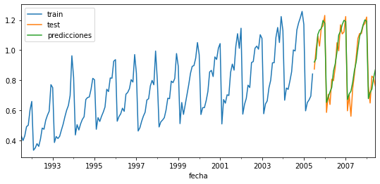

```python
# Gráfico
# ==============================================================================
fig, ax = plt.subplots(figsize=(9, 4))
datos_train.plot(ax=ax, label='train')
datos_test.plot(ax=ax, label='test')
predicciones.plot(ax=ax, label='predicciones')
ax.legend();
```

```python
# Error de test
# ==============================================================================
error_mse = mean_squared_error(
                y_true = datos_test,
                y_pred = predicciones
            )
print(f"Error de test (mse) {error_mse}")
```

```
Error de test (mse) 0.003977043111878048
```

Con la combinación óptima de hiperparámetros se consigue reducir notablemente el error de test.

### Importancia predictores

Dado que el objeto `ForecasterAutoreg` utiliza modelos *scikit-learn*, una vez entrenado, se puede acceder a la importancia de los predictores. Cuando el regresor empleado es un `LinearRegression()`, `Lasso()` o `Ridge()`, la importancia queda reflejada en los [coeficientes](https://www.cienciadedatos.net/documentos/py10-regresion-lineal-python.html#Interpretaci%C3%B3n-del-modelo) del modelo, que se obtienen con el método `get_coef()`. En regresores `GradientBoostingRegressor()` o `RandomForestRegressor()`, la importancia de los predictores está basada en la [reducción de impureza](https://www.cienciadedatos.net/documentos/py08_random_forest_python.html#Importancia-de-los-predictores) y es accesible mediante el método `get_feature_importances()`. En ambos casos, el orden devuelto se corresponde con el de los lags.

```python
# Importancia predictores
# ==============================================================================
impotancia = forecaster_rf.get_feature_importances()
dict(zip(forecaster_rf.lags, impotancia))
```

```
{1: 0.012553886713487061,
 2: 0.08983951332807713,
 3: 0.010659102591406495,
 4: 0.002089457758242796,
 5: 0.0020659673443678165,
 6: 0.0025603607878369916,
 7: 0.002581234419075128,
 8: 0.00692666663137377,
 9: 0.011527319810863246,
 10: 0.02536813007770579,
 11: 0.0179467896103424,
 12: 0.7756201041018168,
 13: 0.0031870877064889024,
 14: 0.014718107972907108,
 15: 0.00787688226587692,
 16: 0.003480591965198101,
 17: 0.0027116142341500264,
 18: 0.0020417148550876244,
 19: 0.0018876654387458749,
 20: 0.004357802386950057}
```

## Forecasting autorregresivo recursivo con variables exógenas

En el ejemplo anterior, se han utilizado como predictores únicamente lags de la propia variable predicha. En ciertos escenarios, es posible disponer de información sobre otras variables, **cuyo valor a futuro se conoce**, y pueden servir como predictoreres adicionales en el modelo.

Siguiendo con el ejemplo anterior, se simula una nueva variable cuyo comportamiento está correlacionado con la serie temporal modelada y que, por lo tanto, se quiere incorporar como predictor. Esto mísmo es aplicable a múltiples variables exógenas.

### Datos

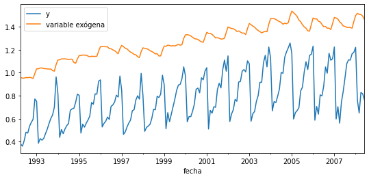

```python
# Descarga de datos
# ==============================================================================
url = 'https://raw.githubusercontent.com/JoaquinAmatRodrigo/skforecast/master/data/h2o_exog.csv'
datos = pd.read_csv(url, sep=',')

# Preparación del dato
# ==============================================================================
datos['fecha'] = pd.to_datetime(datos['fecha'], format='%Y/%m/%d')
datos = datos.set_index('fecha')
datos = datos.asfreq('MS')
datos = datos.sort_index()

fig, ax = plt.subplots(figsize=(9, 4))
datos['y'].plot(ax=ax, label='y')
datos['exog_1'].plot(ax=ax, label='variable exógena')
ax.legend();
```

```python
# Separación datos train-test
# ==============================================================================
steps = 36
datos_train = datos[:-steps]
datos_test  = datos[-steps:]
```

### ForecasterAutoreg

```python
# Crear y entrenar forecaster
# ==============================================================================
forecaster_rf = ForecasterAutoreg(
                    regressor = RandomForestRegressor(random_state=123),
                    lags      = 8
                )

forecaster_rf.fit(y=datos_train['y'], exog=datos_train['exog_1'])
```

### Predicciones

Si el `ForecasterAutoreg` se entrena con una variable exógena, hay que pasarle el valor de esta variable al `predict()`. Por lo tanto, solo es aplicable a escenarios en los que se dispone de información a futuro de la variable exógena.

```python
# Predicciones
# ==============================================================================
predicciones = forecaster_rf.predict(steps=steps, exog=datos_test['exog_1'])
# Se añade el índice a las predicciones
predicciones = pd.Series(data=predicciones, index=datos_test.index)
```

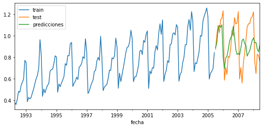

```python
# Gráfico
# ==============================================================================
fig, ax=plt.subplots(figsize=(9, 4))
datos_train['y'].plot(ax=ax, label='train')
datos_test['y'].plot(ax=ax, label='test')
predicciones.plot(ax=ax, label='predicciones')
ax.legend();
```

### Error de las predicciones en el conjunto de test

```python
# Error test
# ==============================================================================
error_mse = mean_squared_error(
                y_true = datos_test['y'],
                y_pred = predicciones
            )
print(f"Error de test (mse): {error_mse}")
```

```
Error de test (mse): 0.03989087922533575
```

### Tuning del modelo

```python
# Grid search de hiperparámetros
# ==============================================================================
forecaster_rf = ForecasterAutoreg(
                    regressor = RandomForestRegressor(random_state=123),
                    lags      = 12 # Este valor será remplazado en el grid search
                 )

param_grid = {'n_estimators': [50, 100, 500],
              'max_depth': [3, 5, 10]}

lags_grid = [5, 12, 20]

resultados_grid = grid_search_forecaster(
                        forecaster  = forecaster_rf,
                        y           = datos_train['y'],
                        exog        = datos_train['exog_1'],
                        param_grid  = param_grid,
                        lags_grid   = lags_grid,
                        steps       = 10,
                        method      = 'cv',
                        metric      = 'mean_squared_error',
                        initial_train_size    = int(len(datos_train)*0.5),
                        allow_incomplete_fold = False,
                        return_best = True,
                        verbose     = False
                    )
```

```
2021-12-01 21:05:26,734 root       INFO  Number of models compared: 27
2021-12-01 21:06:37,048 root       INFO  Refitting `forecaster` using the best found parameters and the whole data set:
lags: [ 1  2  3  4  5  6  7  8  9 10 11 12]
params: {'max_depth': 3, 'n_estimators': 50}
```

```python
# Resultados Grid Search
# ==============================================================================
resultados_grid.head()
```

|  | lags | params | metric | max_depth | n_estimators |
| --- | --- | --- | --- | --- | --- |
| 9 | [1, 2, 3, 4, 5, 6, 7, 8, 9, 10, 11, 12] | {'max_depth': 3, 'n_estimators': 50} | 0.007815 | 3 | 50 |
| 12 | [1, 2, 3, 4, 5, 6, 7, 8, 9, 10, 11, 12] | {'max_depth': 5, 'n_estimators': 50} | 0.007940 | 5 | 50 |
| 20 | [1, 2, 3, 4, 5, 6, 7, 8, 9, 10, 11, 12, 13, 14... | {'max_depth': 3, 'n_estimators': 500} | 0.007944 | 3 | 500 |
| 19 | [1, 2, 3, 4, 5, 6, 7, 8, 9, 10, 11, 12, 13, 14... | {'max_depth': 3, 'n_estimators': 100} | 0.008057 | 3 | 100 |
| 25 | [1, 2, 3, 4, 5, 6, 7, 8, 9, 10, 11, 12, 13, 14... | {'max_depth': 10, 'n_estimators': 100} | 0.008106 | 10 | 100 |

Los mejores resultados se obtienen utilizando una ventana temporal de 12 lags y una configuración de Random Forest {'max_depth': 3, 'n_estimators': 50}.

### Modelo final

Como se ha indicado `return_best=True` en el `grid_search_forecaster()`, tras la búsqueda, el objeto `ForecasterAutoreg` ha sido modificado y entrenado con la mejor combinación encontrada.

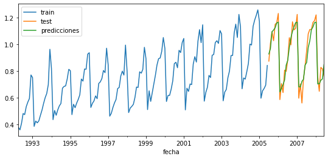

```python
# Predicciones
# ==============================================================================
predicciones = forecaster_rf.predict(steps=steps, exog=datos_test['exog_1'])
# Se añade el índice a las predicciones
predicciones = pd.Series(data=predicciones, index=datos_test.index)

# Gráfico
# ==============================================================================
fig, ax=plt.subplots(figsize=(9, 4))
datos_train['y'].plot(ax=ax, label='train')
datos_test['y'].plot(ax=ax, label='test')
predicciones.plot(ax=ax, label='predicciones')
ax.legend();
```

```python
# Error
# ==============================================================================
error_mse = mean_squared_error(y_true = datos_test['y'], y_pred = predicciones)
print(f"Error de test (mse) {error_mse}")
```

```
Error de test (mse) 0.003965444559763559
```

## Forecasting autorregresivo recursivo con predictores custom

En determinados escenarios, puede ser interesante incorporar otras características de la serie temporal además de los lags, por ejemplo, la media movil de los últimos *n* valores puede servir para capturar la tendencia de la serie.

La clase `ForecasterAutoregCustom` se comporta de forma muy similar a la clase `ForecasterAutoreg` vista en los apartados anteriores pero con la diferencia de que, es el usuario, quien define la función empleada para crear los predictores.

Se repite el primer ejemplo del documento, predecir los últimos 36 meses de la serie temporal, pero esta vez, utilizando como predictores los 10 primeros lags y la media móvil de los últimos 20 meses.

### Datos

```python
# Descarga de datos
# ==============================================================================
url = 'https://raw.githubusercontent.com/JoaquinAmatRodrigo/skforecast/master/data/h2o.csv'
datos = pd.read_csv(url, sep=',')
```

```python
# Preparación del dato
# ==============================================================================
datos['fecha'] = pd.to_datetime(datos['fecha'], format='%Y/%m/%d')
datos = datos.set_index('fecha')
datos = datos.rename(columns={'x': 'y'})
datos = datos.asfreq('MS')
datos = datos['y']
datos = datos.sort_index()
```

```python
# Separación datos train-test
# ==============================================================================
steps = 36
datos_train = datos[:-steps]
datos_test  = datos[-steps:]
```

### ForecasterAutoregCustom

Se crea y entrena un `ForecasterAutoregCustom` a partir de un regresor `RandomForestRegressor`. Para crear los predictores, se emplea la función `create_predictors()` que calcula los primeros 10 lags y la media móvil de los últimos 20 valores.

```python
# Función para calcular los predictores a partir de la serie temporal
# ==============================================================================
def create_predictors(y):
    '''
    Crear los primeros 10 lags.
    Calcular la media móvil de los últimos 20 valores.
    '''

    X_train = pd.DataFrame({'y':y.copy()})
    for i in range(0, 10):
        X_train[f'lag_{i+1}'] = X_train['y'].shift(i)

    X_train['moving_avg'] = X_train['y'].rolling(20).mean()

    X_train = X_train.drop(columns='y').tail(1).to_numpy()

    return X_train
```

Al crear el forecaster, el argumento `window_size` debe ser un valor, como mínimo, tan grande como la ventana que utiliza la función que crea los predictores. En este caso 20.

```python
# Crear y entrenar forecaster
# ==============================================================================
forecaster_rf = ForecasterAutoregCustom(
                    regressor      = RandomForestRegressor(random_state=123),
                    fun_predictors = create_predictors,
                    window_size    = 20
                )

forecaster_rf.fit(y=datos_train)
forecaster_rf
```

```
=======================ForecasterAutoregCustom=======================
Regressor: RandomForestRegressor(random_state=123)
Predictors created with: create_predictors
Window size: 20
Exogenous variable: False, None
Parameters: {'bootstrap': True, 'ccp_alpha': 0.0, 'criterion': 'mse', 'max_depth': None, 'max_features': 'auto', 'max_leaf_nodes': None, 'max_samples': None, 'min_impurity_decrease': 0.0, 'min_impurity_split': None, 'min_samples_leaf': 1, 'min_samples_split': 2, 'min_weight_fraction_leaf': 0.0, 'n_e…
```

### Predicciones

```python
# Predicciones
# ==============================================================================
steps = 36
predicciones = forecaster_rf.predict(steps=steps)
# Se añade el índice temporal a las predicciones
predicciones = pd.Series(data=predicciones, index=datos_test.index)
```

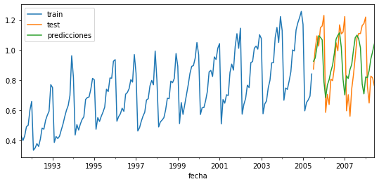

```python
# Gráfico
# ==============================================================================
fig, ax = plt.subplots(figsize=(9, 4))
datos_train.plot(ax=ax, label='train')
datos_test.plot(ax=ax, label='test')
predicciones.plot(ax=ax, label='predicciones')
ax.legend();
```

### Error de las predicciones en el conjunto de test

```python
# Error
# ==============================================================================
error_mse = mean_squared_error(
                y_true = datos_test,
                y_pred = predicciones
            )
print(f"Error de test (mse): {error_mse}")
```

```
Error de test (mse): 0.04487765885818191
```

### Ajuste de hiperparámetros (*tuning*)

Al utilizar la función `grid_search_forecaster()` con un `ForecasterAutoregCustom`, no se indica el argumento `lags_grid`.

```python
# Grid search de hiperparámetros
# ==============================================================================
forecaster_rf = ForecasterAutoregCustom(
                    regressor      = RandomForestRegressor(random_state=123),
                    fun_predictors = create_predictors,
                    window_size    = 20
                )

# Hiperparámetros del regresor
param_grid = {'n_estimators': [100, 500],
              'max_depth': [3, 5, 10]}

resultados_grid = grid_search_forecaster(
                        forecaster  = forecaster_rf,
                        y           = datos_train,
                        param_grid  = param_grid,
                        steps       = 10,
                        method      = 'cv',
                        metric      = 'mean_squared_error',
                        initial_train_size    = int(len(datos_train)*0.5),
                        allow_incomplete_fold = True,
                        return_best = True,
                        verbose     = False
                    )
```

```
2021-12-01 21:07:11,078 root       INFO  Number of models compared: 6
2021-12-01 21:08:01,941 root       INFO  Refitting `forecaster` using the best found parameters and the whole data set:
lags: custom predictors
params: {'max_depth': 10, 'n_estimators': 500}
```

```python
# Resultados Grid Search
# ==============================================================================
resultados_grid
```

|  | lags | params | metric | max_depth | n_estimators |
| --- | --- | --- | --- | --- | --- |
| 5 | custom predictors | {'max_depth': 10, 'n_estimators': 500} | 0.022736 | 10 | 500 |
| 3 | custom predictors | {'max_depth': 5, 'n_estimators': 500} | 0.022742 | 5 | 500 |
| 4 | custom predictors | {'max_depth': 10, 'n_estimators': 100} | 0.023564 | 10 | 100 |
| 2 | custom predictors | {'max_depth': 5, 'n_estimators': 100} | 0.024030 | 5 | 100 |
| 1 | custom predictors | {'max_depth': 3, 'n_estimators': 500} | 0.025694 | 3 | 500 |
| 0 | custom predictors | {'max_depth': 3, 'n_estimators': 100} | 0.026545 | 3 | 100 |

### Modelo final

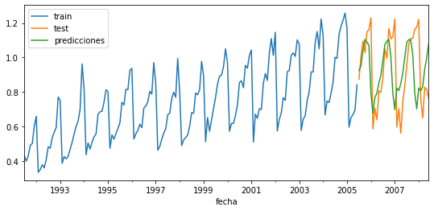

```python
# Predicciones
# ==============================================================================
predicciones = forecaster_rf.predict(steps=steps)
# Se añade el índice a las predicciones
predicciones = pd.Series(data=predicciones, index=datos_test.index)

# Gráfico
# ==============================================================================
fig, ax = plt.subplots(figsize=(9, 4))
datos_train.plot(ax=ax, label='train')
datos_test.plot(ax=ax, label='test')
predicciones.plot(ax=ax, label='predicciones')
ax.legend();
```

```python
# Error
# ==============================================================================
error_mse = mean_squared_error(y_true = datos_test, y_pred = predicciones)
print(f"Error de test (mse) {error_mse}")
```

```
Error de test (mse) 0.044590618568342955
```

## Direct multi-step forecasting

Los modelos `ForecasterAutoreg` y `ForecasterAutoregCustom` siguen una estrategia de predicción recursiva en la que, cada nueva predicción, se basa en la predicción anterior. Una alternativa es entrenar un modelo para cada uno de los *steps* que se desea predecir. Esta estrategia, normalmente conocida como *direct multi-step forecasting*, es computacionalmente más costosa que la recursiva puesto que requiere entrenar varios modelos. Sin embargo, en algunos escenarios, consigue mejores resultados. Este tipo de modelos pueden obtenerse con la clase `ForecasterAutoregMultiOutput` y pueden incluir también una o múltiples variables exógenas.

### Datos

```python
# Descarga de datos
# ==============================================================================
url = 'https://raw.githubusercontent.com/JoaquinAmatRodrigo/skforecast/master/data/h2o.csv'
datos = pd.read_csv(url, sep=',')

# Preparación del dato
# ==============================================================================
datos['fecha'] = pd.to_datetime(datos['fecha'], format='%Y/%m/%d')
datos = datos.set_index('fecha')
datos = datos.rename(columns={'x': 'y'})
datos = datos.asfreq('MS')
datos = datos['y']
datos = datos.sort_index()
```

```python
# Separación datos train-test
# ==============================================================================
steps = 36
datos_train = datos[:-steps]
datos_test  = datos[-steps:]
```

### ForecasterAutoregMultiOutput

A diferencia de cuando se utiliza `ForecasterAutoreg` o `ForecasterAutoregCustom`, en los modelos de tipo `ForecasterAutoregMultiOutput` hay que indicar, en el momento de su creación, el número de *steps* que se quieren predecir. Esto significa que, el número de predicciones obtenidas al ejecutar el método `predict()` es siempre el mismo.

```python
# Grid search de hiperparámetros
# ==============================================================================
forecaster_rf = ForecasterAutoregMultiOutput(
                    regressor = Lasso(random_state=123),
                    steps     = 36,
                    lags      = 8 # Este valor será remplazado en el grid search
                )

param_grid = {'alpha': np.logspace(-5, 5, 10)}

lags_grid = [5, 12, 20]

resultados_grid = grid_search_forecaster(
                        forecaster  = forecaster_rf,
                        y           = datos_train,
                        param_grid  = param_grid,
                        lags_grid = lags_grid,
                        steps       = 36,
                        method      = 'cv',
                        metric      = 'mean_squared_error',
                        initial_train_size    = int(len(datos_train)*0.5),
                        allow_incomplete_fold = False,
                        return_best = True,
                        verbose     = False
                    )
```

```
2021-12-01 21:08:25,434 root       INFO  Number of models compared: 30
2021-12-01 21:08:26,803 root       INFO  Refitting `forecaster` using the best found parameters and the whole data set:
lags: [ 1  2  3  4  5  6  7  8  9 10 11 12]
params: {'alpha': 0.0016681005372000592}
```

```python
# Resultados Grid Search
# ==============================================================================
resultados_grid.head()
```

|  | lags | params | metric | alpha |
| --- | --- | --- | --- | --- |
| 12 | [1, 2, 3, 4, 5, 6, 7, 8, 9, 10, 11, 12] | {'alpha': 0.0016681005372000592} | 0.009650 | 0.001668 |
| 22 | [1, 2, 3, 4, 5, 6, 7, 8, 9, 10, 11, 12, 13, 14... | {'alpha': 0.0016681005372000592} | 0.009872 | 0.001668 |
| 11 | [1, 2, 3, 4, 5, 6, 7, 8, 9, 10, 11, 12] | {'alpha': 0.0001291549665014884} | 0.012075 | 0.000129 |
| 10 | [1, 2, 3, 4, 5, 6, 7, 8, 9, 10, 11, 12] | {'alpha': 1e-05} | 0.012371 | 0.000010 |
| 21 | [1, 2, 3, 4, 5, 6, 7, 8, 9, 10, 11, 12, 13, 14... | {'alpha': 0.0001291549665014884} | 0.015304 | 0.000129 |

Los mejores resultados se obtienen utilizando una ventana temporal de 12 lags y una configuración de Lasso {'alpha': 0.001668}.

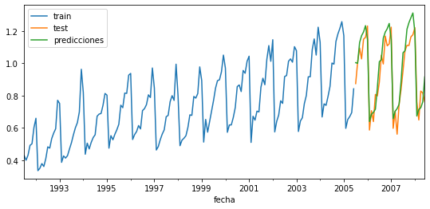

```python
# Predicciones
# ==============================================================================
predicciones = forecaster_rf.predict()
# Se añade el índice a las predicciones
predicciones = pd.Series(data=predicciones, index=datos_test.index)

# Gráfico
# ==============================================================================
fig, ax = plt.subplots(figsize=(9, 4))
datos_train.plot(ax=ax, label='train')
datos_test.plot(ax=ax, label='test')
predicciones.plot(ax=ax, label='predicciones')
ax.legend();
```

```python
# Error
# ==============================================================================
error_mse = mean_squared_error(y_true = datos_test, y_pred = predicciones)
print(f"Error de test (mse) {error_mse}")
```

```
Error de test (mse) 0.008363774087426282
```

## Backtesting

El proceso de [*Backtesting*](https://joaquinamatrodrigo.github.io/skforecast/0.3/guides/cross-validation-backtest.html) consiste en simular el comportamiento que habría tenido el modelo si se hubiese ido ejecutando de forma recurrente, por ejemplo, prediciendo un total de 9 años a intervalos de 3 años (36 meses). Este tipo de evaluación puede aplicarse fácilmente con la función `backtesting_forecaster()`. Esta función devuelve, además de las predicciones, una métrica de error.

```python
# Backtesting
# ==============================================================================
n_test = 36*3 # Se separan para el backtest los últimos 9 años
datos_train = datos[:-n_test]
datos_test  = datos[-n_test:]

steps = 36 # Se utilizan folds de 3 años (36 meses)
regressor = LinearRegression()
forecaster = ForecasterAutoreg(regressor=regressor, lags=15)

metric, predicciones_backtest = backtesting_forecaster(
                                    forecaster = forecaster,
                                    y          = datos,
                                    initial_train_size = len(datos_train),
                                    steps      = steps,
                                    metric     = 'mean_squared_error',
                                    verbose    = True
                               )

print(f"Error de backtest: {metric}")
```

```
Number of observations used for training: 96
Number of observations used for testing: 108
    Number of folds: 3
    Number of steps per fold: 36
Error de backtest: [0.0202643]
```

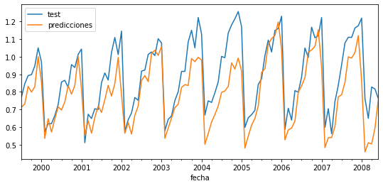

```python
# Se añade el índice temporal a las predicciones
predicciones_backtest = pd.Series(data=predicciones_backtest, index=datos_test.index)
fig, ax = plt.subplots(figsize=(9, 4))
#datos_train.plot(ax=ax, label='train')
datos_test.plot(ax=ax, label='test')
predicciones_backtest.plot(ax=ax, label='predicciones')
ax.legend();
```

## Intervalos de predicción

Un intervalo de predicción define el intervalo dentro del cual es de esperar que se encuentre el verdadero valor de $y$ con una determinada probabilidad.

Rob J Hyndman y George Athanasopoulos, listan en su libro *Forecasting: Principles and Practice* [mútiples formas de estimar intervalos de predicción](https://otexts.com/fpp2/prediction-intervals.html), la mayoría los cuales requieren que los resudios (errores) del modelo se distribuyan de forma normal. Cuando no se puede asumir esta propiedad, se puede recurrir a *bootstrapping*, que solo asume que los residuos no están correlacionados. Este es el método utilizado en la librería **Skforecast** para los modelos de tipo `ForecasterAutoreg` y `ForecasterAutoregCustom`.

```python
# Descarga de datos
# ==============================================================================
url = ('https://raw.githubusercontent.com/JoaquinAmatRodrigo/skforecast/master/data/h2o.csv')
datos = pd.read_csv(url, sep=',')

# Preparación del dato
# ==============================================================================
datos['fecha'] = pd.to_datetime(datos['fecha'], format='%Y/%m/%d')
datos = datos.set_index('fecha')
datos = datos.rename(columns={'x': 'y'})
datos = datos.asfreq('MS')
datos = datos['y']
datos = datos.sort_index()

# Separación datos train-test
# ==============================================================================
steps = 36
datos_train = datos[:-steps]
datos_test  = datos[-steps:]
```

```
Error de test (mse): 0.011051937043503714
```

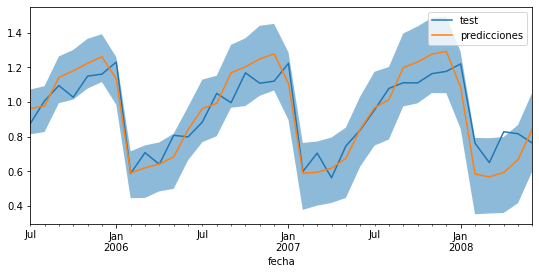

```python
# Crear y entrenar forecaster
# ==============================================================================
forecaster = ForecasterAutoreg(
                    regressor=LinearRegression(),
                    lags=15
                )

forecaster.fit(y=datos_train)

# Intervalos de predicción
# ==============================================================================
predicciones = forecaster.predict_interval(
                    steps    = steps,
                    interval = [1, 99],
                    n_boot   = 1000
              )

# Se añade índice datetime
predicciones = pd.DataFrame(data=predicciones, index=datos_test.index)

# Error de predicción
# ==============================================================================
error_mse = mean_squared_error(
                y_true = datos_test,
                y_pred = predicciones.iloc[:, 0]
            )
print(f"Error de test (mse): {error_mse}")

# Gráfico
# ==============================================================================
fig, ax=plt.subplots(figsize=(9, 4))
#datos_train.plot(ax=ax, label='train')
datos_test.plot(ax=ax, label='test')
predicciones.iloc[:, 0].plot(ax=ax, label='predicciones')
ax.fill_between(predicciones.index,
                predicciones.iloc[:, 1],
                predicciones.iloc[:, 2],
                alpha=0.5)
ax.legend();
```

```
Number of observations used for training: 96
Number of observations used for testing: 108
    Number of folds: 3
    Number of steps per fold: 36
[0.0202643]
```

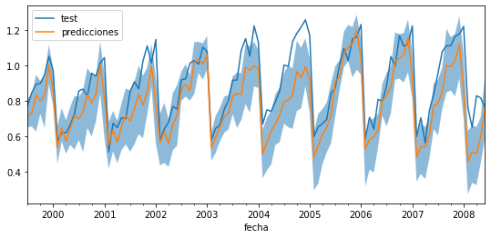

```python
# Backtest con intervalos de predicción
# ==============================================================================
n_test = 36*3
datos_train = datos[:-n_test]
datos_test  = datos[-n_test:]

steps = 36
regressor = LinearRegression()
forecaster = ForecasterAutoreg(regressor=regressor, lags=15)

metric, predicciones = backtesting_forecaster_intervals(
                            forecaster = forecaster,
                            y          = datos,
                            initial_train_size = len(datos_train),
                            steps      = steps,
                            metric     = 'mean_squared_error',
                            interval            = [1, 99],
                            n_boot              = 100,
                            in_sample_residuals = True,
                            verbose             = True
                       )

print(metric)

# Se añade índice datetime
predicciones = pd.DataFrame(data=predicciones, index=datos_test.index)

# Gráfico
# ==============================================================================
fig, ax = plt.subplots(figsize=(9, 4))
#datos_train.plot(ax=ax, label='train')
datos_test.plot(ax=ax, label='test')
predicciones.iloc[:, 0].plot(ax=ax, label='predicciones')
ax.fill_between(predicciones.index,
                predicciones.iloc[:, 1],
                predicciones.iloc[:, 2],
                alpha=0.5)
ax.legend();
```

## Cargar y guardar modelos

Los modelos generados con [**Skforecast**](https://joaquinamatrodrigo.github.io/skforecast/) se pueden cargar y guardar usando las librerías **pickle** o **joblib**. A continuación se muestra un ejemplo sencillo utilizando **joblib**.

```python
# Crear forecaster
forecaster = ForecasterAutoreg(LinearRegression(), lags=3)
forecaster.fit(y=pd.Series(np.arange(50)))
```

```python
# Guardar modelo
dump(forecaster, filename='forecaster.py')
```

```
['forecaster.py']
```

```python
# Cargar modelo
forecaster_cargado = load('forecaster.py')
```

```python
# Predicciones
forecaster_cargado.predict(steps=5)
```

```
array([50., 51., 52., 53., 54.])
```

## Información de sesión

```python
import session_info
session_info.show(html=False)
```

```
-----
ipykernel           6.4.1
joblib              1.0.1
matplotlib          3.4.3
numpy               1.19.5
pandas              1.3.0
session_info        1.0.0
skforecast          0.3.0
sklearn             0.24.2
statsmodels         0.13.0
-----
IPython             7.27.0
jupyter_client      6.1.12
jupyter_core        4.7.1
jupyterlab          3.1.11
notebook            6.3.0
-----
Python 3.7.10 (default, Feb 26 2021, 18:47:35) [GCC 7.3.0]
Linux-5.11.0-40-generic-x86_64-with-debian-bullseye-sid
-----
Session information updated at 2021-12-01 21:10
```

## Bibliografía

Hyndman, R.J., & Athanasopoulos, G. (2021) Forecasting: principles and practice, 3rd edition, OTexts: Melbourne, Australia. [libro](https://otexts.com/fpp3/)

Time Series Analysis and Forecasting with ADAM Ivan Svetunkov [libro](https://openforecast.org/adam/)

Python Data Science Handbook by Jake VanderPlas [libro](https://www.amazon.es/gp/product/1491912057/ref=as_li_qf_asin_il_tl?ie=UTF8&tag=cienciadedato-21&creative=24630&linkCode=as2&creativeASIN=1491912057&linkId=73620d22f9d4a0a76d27592dabf13c83)

Python for Finance: Mastering Data-Driven Finance [libro](https://www.amazon.es/gp/product/1492024333/ref=as_li_qf_asin_il_tl?ie=UTF8&tag=cienciadedato-21&creative=24630&linkCode=as2&creativeASIN=1492024333&linkId=70c3175ad015970cd1c2328b7a40a055)

[**skforecast**](https://joaquinamatrodrigo.github.io/skforecast/)

**¿Cómo citar este documento?**

Forecasting series temporales con Python y Scikitlearn by Joaquín Amat Rodrigo, available under a Attribution 4.0 International (CC BY 4.0) at https://www.cienciadedatos.net/py27-forecasting-series-temporales-python-scikitlearn.html

This work by Joaquín Amat Rodrigo is licensed under a [Creative Commons Attribution 4.0 International License](http://creativecommons.org/licenses/by/4.0/).